# Homework 6 - Corona Brasil

Fellipe Porto

24/12/2020

```r
# carregando pacotes

library(dplyr)
```

```r
library(tidyr)
library(ggplot2)
library(readxl)
library(patchwork)
library(scales)
library(ggthemes)
library(extrafont)
library(zoo)
corona = read.csv2('HIST_PAINEL_COVIDBR_26dez2020.csv',
                   colClasses = c("character", # Regiao
                                  "character", # Estado
                                  "character", # Municipio
                                  "numeric", # coduf
                                  "numeric", # codmun
                                  "numeric", # codRegiaoSaude
                                  "character", # nomeRegiaoSaude
                                  "Date", # data
                                  "numeric", # semanaEpi
                                  "numeric", # populacaoTCU2019
                                  "numeric", # casosAcumulado
                                  "numeric", # casosNovos
                                  "numeric", # obitosAcumulado
                                  "numeric", # obitosNovos
                                  "numeric", # Recuperadosnovos
                                  "numeric", # emAcompanhamentoNovos
                                  "factor" # interior/metropolitana
                   ), encoding = "UTF-8")
```

O estudo de caso para essa atividade será a respeito do estado do Mato Grosso do Sul. Um estado que não está entre os mais atingidos, tendo números de casos e óbitos bem menores do que os demais, mas que vê o aumento nos casos após uma rápida queda.

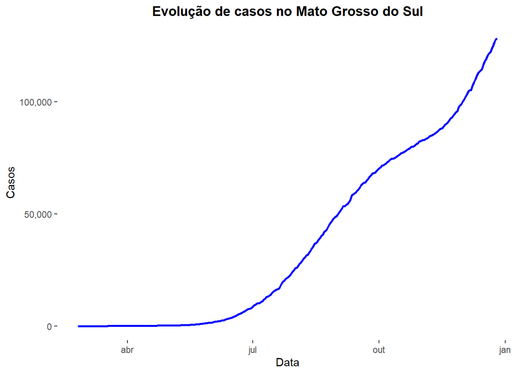

```r
# filtrando estado

coronaMS <- corona %>%
  filter(!is.na(estado), is.na(codmun), estado=="MS")


# evolução de casos

coronaMS %>%
  ggplot() +
  geom_line(mapping = aes(data, casosAcumulado), color = 'blue', size = 1)+
  theme_tufte()+
  theme(text = element_text(family = 'Rubik'),
        legend.position = 'top',
        plot.title = element_text(hjust = 0.5,
                                  face = "bold"),
        plot.subtitle = element_text(hjust = 0.5))+
  labs(title = 'Evolução de casos no Mato Grosso do Sul',
       x = 'Data',
       y = 'Casos')+
  scale_y_continuous(labels = comma)
```

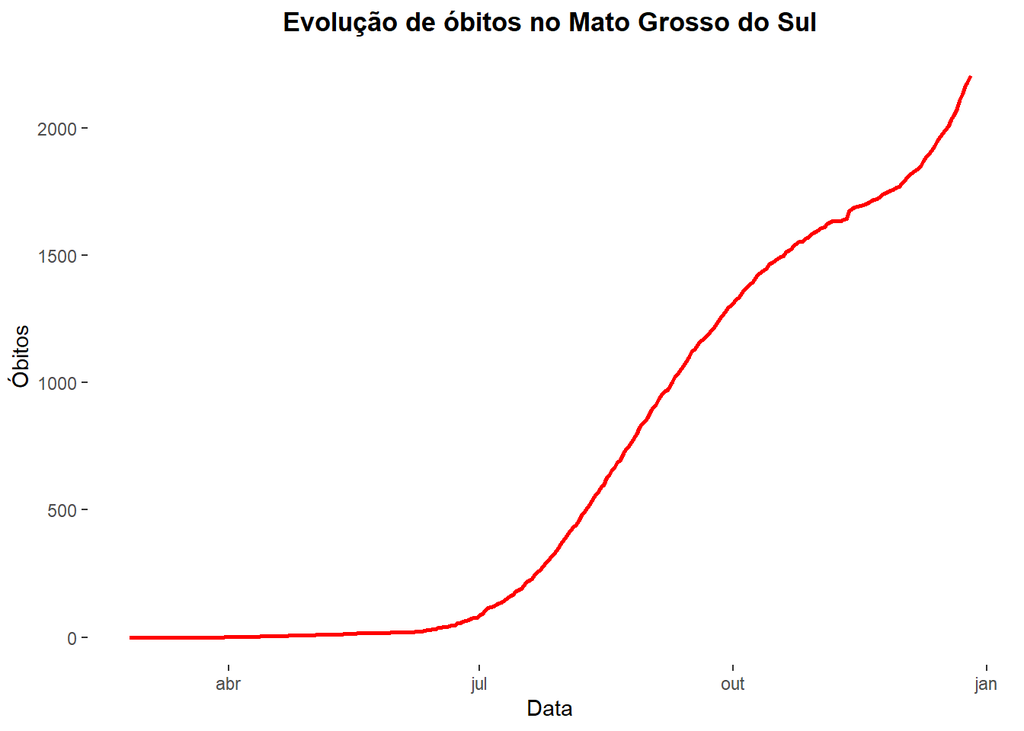

```r
# evolução de óbitos

coronaMS %>%
  ggplot() +
  geom_line(mapping = aes(data, obitosAcumulado), color = 'red', size = 1)+
  theme_tufte()+
  theme(text = element_text(family = 'Rubik'),
        legend.position = 'top',
        plot.title = element_text(hjust = 0.5,
                                  face = "bold"),
        plot.subtitle = element_text(hjust = 0.5))+
  labs(title = 'Evolução de óbitos no Mato Grosso do Sul',
       x = 'Data',
       y = 'Óbitos')
```

Como é possível observar, as linhas seguem subindo, apesar de uma tímida mudança após outubro, que poderia significar a queda na série, mas que voltou a subir posteriormente. Essa pequena variação é observada nos dois gráficos, sendo no de casos um pouco mais perceptível. Os gráficos a seguir ajudarão a entender como foi esse período com mais detalhes.

[output not shown]

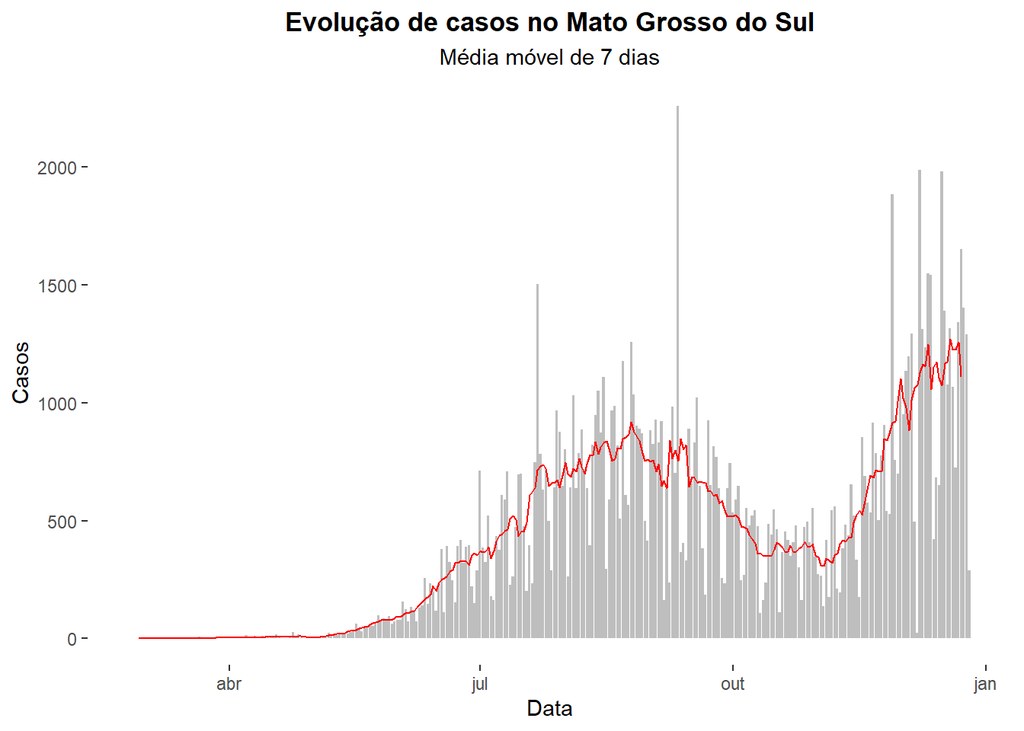

```r
# media movel de casos

coronaMS %>%
  mutate(mediaMovel = rollmean(casosNovos, k = 7, fill = NA)) %>%
  ggplot(aes(x=data)) +
  geom_bar(aes(y = casosNovos), stat = "identity", fill = "grey") +
  geom_line(mapping=aes(x = data, y = mediaMovel), color="red") +
  theme_tufte()+
  theme(text = element_text(family = 'Rubik'),
        legend.position = 'top')+
  labs(title = 'Evolução de casos no Mato Grosso do Sul',
       subtitle = 'Média móvel de 7 dias',
       x = 'Data',
       y = 'Casos')+
  theme(plot.title = element_text(hjust = 0.5, face = "bold"),
        plot.subtitle = element_text(hjust = 0.5))
```

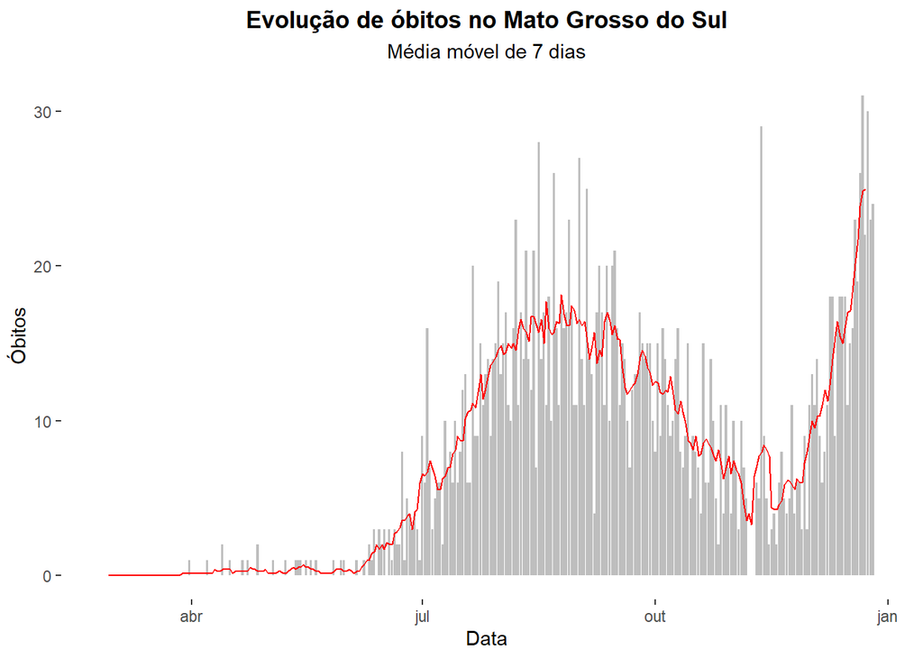

```r
# media movel de mortes

coronaMS %>%
  mutate(mediaMovel = rollmean(obitosNovos, k = 7, fill = NA)) %>%
  ggplot(aes(x=data)) +
  geom_bar(aes(y = obitosNovos), stat = "identity", fill = "grey") +
  geom_line(mapping=aes(x = data, y = mediaMovel), color="red") +
  theme_tufte()+
  theme(text = element_text(family = 'Rubik'),
        legend.position = 'top')+
  labs(title = 'Evolução de óbitos no Mato Grosso do Sul',
       subtitle = 'Média móvel de 7 dias',
       x = 'Data',
       y = 'Óbitos')+
  theme(plot.title = element_text(hjust = 0.5, face = "bold"),
        plot.subtitle = element_text(hjust = 0.5))
```

A partir desses últimos gráficos fica mais claro o caminho que os novos casos e óbitos seguiram: uma queda significativa acompanhada de um aumento, que agora se mostra com números maiores do que o do momento anterior à queda, tendo inclusive picos mais altos. O ponto importante aqui é perceber que os óbitos estão acompanhando o aumento dos casos, o que não se observou em outros lugares onde a “segunda onda” foi analisada.

A seguir veremos quais foram os munícipios mais afetados.

```r
# municipios mais afetados

### casos

municipio <- corona %>%
  filter(!is.na(estado), !is.na(municipio), estado == 'MS')

top5 <- municipio %>%
  select(municipio, casosNovos)%>%
  group_by(municipio) %>%
  summarise(total = sum(casosNovos)) %>%
  arrange(desc(total))%>%
  top_n(6)
```

[output not shown]

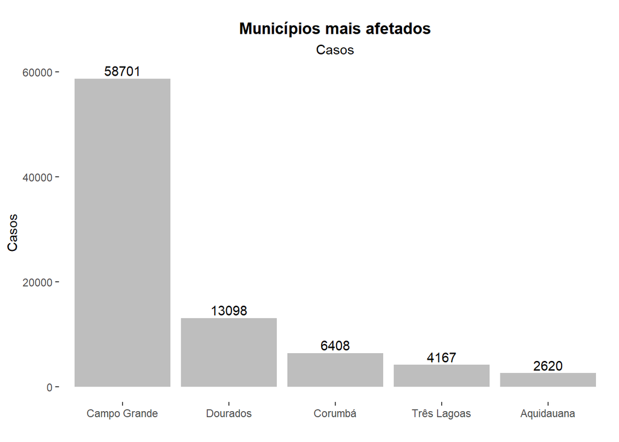

```r
top5 <- top5[-1,]

top5 %>% ggplot(mapping = aes(x = reorder(municipio, -total), y = total))+
  geom_bar(stat = "identity", fill = 'grey')+
  labs(title = "Municípios mais afetados",
    subtitle = "Casos",
    x = "",
    y = "Casos",
    tag = "")+
  geom_text(aes(label = total, vjust = -0.3) )+
  theme_tufte()+
  theme(plot.title = element_text(hjust = 0.5, face = "bold"),
        plot.subtitle = element_text(hjust = 0.5),
        text = element_text(family = 'Rubik'))
```

```r
### obitos

top5_m <- municipio %>%
  select(municipio, obitosNovos)%>%
  group_by(municipio) %>%
  summarise(total = sum(obitosNovos)) %>%
  arrange(desc(total))%>%
  top_n(6)
```

[output not shown]

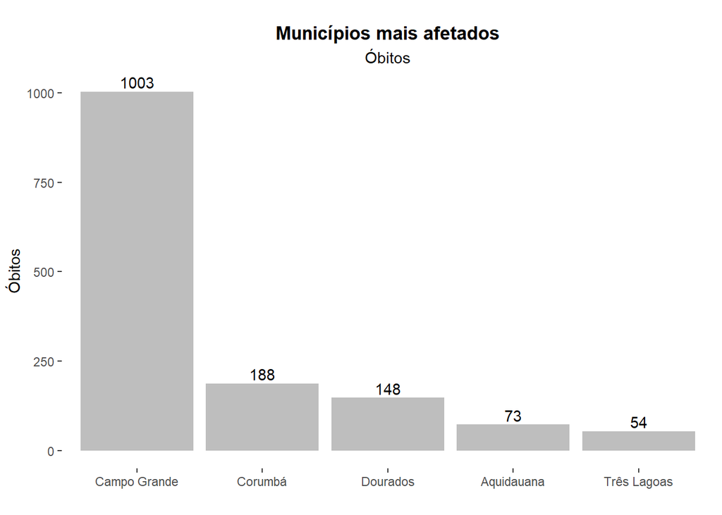

```r
top5_m <- top5_m[-1,]

top5_m %>% ggplot(mapping = aes(x = reorder(municipio, -total), y = total))+
  geom_bar(stat = "identity", fill = 'grey')+
  labs(title = "Municípios mais afetados",
       subtitle = "Óbitos",
       x = "",
       y = "Óbitos",
       tag = "")+
  geom_text(aes(label = total, vjust = -0.3) )+
  theme_tufte()+
  theme(plot.title = element_text(hjust = 0.5, face = "bold"),
        plot.subtitle = element_text(hjust = 0.5),
        text = element_text(family = 'Rubik'))
```

Dentre os municípios mais afetados, 4 deles - Campo Grande, Dourados, Três Lagoas, e Corumbá, respectivamente - fazem parte dos [5 mais populosos do estado](https://www.tererenews.com.br/home/municipios-de-mato-grosso-do-sul/). Campo Grande concentra a maioria dos casos e óbitos por COVID 19 no estado.